# Biological control of important fungal diseases of potato and raspberry by two *Bacillus velezensis* strains

Lourdes Arellano M, Antonia Fernandes, Juliana Cajiao and Rosario Heribia

20/01/2022

```r
library(knitr)
knitr::opts_chunk$set(
  echo = TRUE,
  results = 'markup',
  fig.path = "results/",
  fig.width = 10,
  fig.height = 6.1803,
  dev = "png",
  dev.args = list(type = "cairo"),
  dpi = 100)
```

## Introduction

Fungal phytopathogens affect agricultural crops lead to a improtant decrease in their quality and production. They act as a threat to crops through various mechanisms of pathogenesis that compromise the immune system of the plants. The use of fungicides against fungal plant diseases improves crop yield, quality, and shelf-life (Brauer *et al*., 2019). Nevertheless, the irrational uses of this products triggers to health problems, and can also cause severe damage to the environment. Accumulation of pesticides in the environment disrupts the ecological balance and raises pathogen resistance to pesticides. Thus, the application of fungicides in agriculture should be under strict regulation to ensure that commercialized foods are safe for consumption and pose negligible risks of acute toxicity due to carry-over (Brauer *et al*., 2019).

In the case of potato and raspberry plants, they are affected by important diseases as stem canker and black scurf, causes by the fungi *Rhizoctonia solani* and *Didymella applanata*. Recently, two strains of the bacteria *Bacillus velezensis*, specifically BZR 336g and BZR 517, have been tested as potential biological control of these diseases (Asaturova et al., 2020).

*Bacillus velezensis*, an antagonistic bacteria produces several antimicrobial compounds as secondary metabolites against phytopathogens. *B. velezensis* produces spores, which can be used for developing an effective biopesticide. Previously, many studies have demonstrated that several secondary metabolites produced by antagonistic bacteria, play key roles in the control of various phytopathogens. Furthermore, *Bacillus* spp., have been found to produce cyclic lipopeptides (CLPs), which play a key role in antimicrobial activity (Soo Kim *et al*., 2021).

Different methodologies can be applied for the evaluation of the effectiveness of pesticides with different factors and levels; and for this, a variance test must be carried out. An example is Duncan’s test, which is used to compare all pairs of means. It was first developed by Duncan in 1951 but later was modified by himself, generating what is now called Duncan’s New Multiple Range Method.

To apply this test, the following stages must be passed: determine the standard error (standard deviation) of each mean; obtained from the Anova table. Then, with the degrees of freedom of the error and the level of significance, the values, intervals or standardized significant amplitudes are determined using Duncan’s tables of standardized amplitudes, then the minimum significant amplitudes are determined. Following this, the average results of the experiment are ordered in increasing order and the ordered means are compared: The highest average, with the lowest, comparing this difference with the least significant interval.

This process continues until the differences between all possible pairs have been compared. If an observed difference is greater than the minimum significant interval, it is concluded that the pair of means compared are significantly different (UNAL, 2021).

Another variance test that can be applied is the Tukey test. This method was proposed by Tukey (1952) and is very similar in application to the DMS test, except for the fact that instead of using the distributions as the basis for making comparisons, the standardized or studentized range distribution is used. In this test, a single value is used against which all possible pairs of means are compared. Tukey’s comparison method was reformed by Kramer (1956) for cases in which the number of replicas is not equal. This method is known as the Tukey-Kramer method. (UNAL, 2021).

By the other hand, the Shapiro-Wilks test poses the null hypothesis that a sample comes from a normal distribution. The Shapiro-Wilks test poses the null hypothesis that a sample comes from a normal distribution. This test attempts to reject the null hypothesis according to the level of significance. Therefore, if the significance is greater than 0.05, the null hypothesis is overcome, and if it is less than this value, the alternate hypothesis is accepted and it could then be stated that the data do not follow a normal distribution (UNAL, 2021).

It is important to highlight that the study of beneficial microorganisms to create new biological formulations for plant protection is typically conducted under the same ecological and geographical conditions in which the microorganisms were isolated. Thus, effect of this bacteria has been demonstrated as a biological control in crops such as tomato and in specific conditions. However, its potential use as a pesticide in potatoes and raspberries is unknown. The main objective of this work was to demonstrate the potential effect of *B. velezensis* strains against *R. solani*, as a biological control in raspeberry and potatoa and its potential effect on potato crop growth. The strains were isolated in southern Russia on suppressing *Rhizoctonia* disease on potato and spur blight on red raspberry in Western Siberia, which is a geographically distant region with much more severe climate conditions (Asaturova *et al*., 2020).

For this, different experiments and scenarios were carried out. Thus, the potential effect was measured through the antifungal activity of *B. velezensis* against *R. solani* *in vitro*, by applying different treatments in different proportions (quantity) of colony units. The evaluation of the effect of *B. velezensis* strains on the incidence and severity of the disease was evaluated through morphometric parameters caused by *R. solani* in two potato cultivars differentiated by resistance to the disease, during the growing seasons 2015 and 2016 in Western Siberia. Finally, to test the potential increase in potato crop, the biomass distribution of the daughter tubers of two potato cultivars and the total yield were measured during the 2015 and 2016 growing seasons in Western Siberia.

The diameter of the colonies (cm) was measured at 3, 5 and 7 days for *R. solani* and *D. applanata* under the application of the strains: *Bacillus velezensis* BZR 336g and BZR 517 at three different concentrations: 10^4, 10^5 and 10^6 CFU/ml. Disease incidence and severity was measured in percentage in the years 2015 and 2016, in three different treatments: control, BZR 336 g strain and BZR 517 strain, at weeks 4, 6 and 10 after sowing.

Morphometric parameters of two different cultivars (Svitanok kievskiy and Yuna) were measured, such as the total height of the plants (cm) and the number of stems developed with the same factors and levels previously mentioned.

In these same two cultivars the biomass distribution by fractions was measured, in order to measure the plant grow capacity, and they were divided in tree fraction categories: small (less than 35 g), medium (36–180 g), or large (more than 180 g). Yields were determined by weighing all daughter tubers from each plot in the both years. For statistical tests, all data were analyzed performing Duncan and Tukey tests.

## Objectives

Demonstrate the potential effect of *B. velezensis* strains against *R. solani* as a biological control, and a potential increasement in the plant growth of potato.

Also in this review, the aim of this group is to compare the analysis done in the article between the Duncan and Turkey tests to understand why Duncan was used in the article.

## Hypothesis

*B. velezensis* strains can be used as biological control agents against *R. solani*, and increase significantly the plant growth of potato. Moreover, there is no significant difference between the results obtained through the Duncan and Turkey test.

## Methods

**1. Dowload Data:** First, dowload the raw data of the paper that is in the link: https://dfzljdn9uc3pi.cloudfront.net/2021/11578/1/peerj-55829-Raw_data.xls

**Article:** https://peerj.com/articles/11578/#

```r
if(!dir.exists("data")) dir.create("data")
# download.file("https://dfzljdn9uc3pi.cloudfront.net/2021/11578/1/peerj-55829-Raw_data.xls",
#               "data/rawdata.xls")
```

**2. Open and Arrange Data:** For this step, it was used the package “Readxl” to charge the excel file. Each sheet of excel was opened indicating its name and the range required. In some sheets it was use the function “fill” to fill the cells that were empty. Also some names of variables were changed with “rename” and “pivot longer” was used to increase the number of rows or to decrease the number of columns.The potence format was changed. Finally, some new sheets were created why others where joined or deleted in order to have the data arranged.

```r
library(readxl)
#Open sheets with ranges
AntagonisticActivity <-
  read_excel("data/peerj-55829-Raw_data.xls",
             sheet = "Antagonistic activity",
             range = "A3:E38")
DiseaseIncidenceAndSeverity <- read_excel("data/peerj-55829-Raw_data.xls",
                                          sheet = "disease incidence and severity",
                                          range = "A4:N40")
```

```
## * `` -> ...6
## * `` -> ...7
## * `` -> ...8
## * `` -> ...9
## * `` -> ...11
## * ...
```

```r
MorphometricCharactOfPotato <- read_excel("data/peerj-55829-Raw_data.xls",
                                          sheet = "morphometric charact of potato",)
```

```
## * `` -> ...6
## * `` -> ...7
## * `` -> ...8
## * `` -> ...9
## * `` -> ...11
## * ...
```

```r
BiomassDistribution <- read_excel("data/peerj-55829-Raw_data.xls",sheet = "biomass distribution")
```

```
## * `` -> ...6
## * `` -> ...7
## * `` -> ...8
## * `` -> ...9
```

```r
YieldOfPotato <- read_excel("data/peerj-55829-Raw_data.xls",
                            sheet = "yield of potato",
                            range = "B3:I15")
```

```
## * `` -> ...5
## * `` -> ...6
## * `` -> ...7
## * `` -> ...8
```

```r
#Fill
library(tidyr)
library(dplyr)
AntagonisticActivity <- AntagonisticActivity %>% fill(everything(), .direction = "down")
BiomassDistribution <- BiomassDistribution %>% fill(everything(), .direction = "down")
DiseaseIncidenceAndSeverity <- DiseaseIncidenceAndSeverity %>% fill(everything(), .direction = "down")
MorphometricCharactOfPotato <- MorphometricCharactOfPotato %>% fill(everything(), .direction = "down")
YieldOfPotato <- YieldOfPotato %>% fill(everything(), .direction = "down")

#Rename
library(dplyr)
names(AntagonisticActivity)[names(AntagonisticActivity) == 'strain'] <- "Strain"
names(AntagonisticActivity)[names(AntagonisticActivity) == 'CFU/ml'] <- "Concentration"

#Pivot longer
AntagonisticActivity <- pivot_longer(AntagonisticActivity,cols= c("3d", "5d", "7d"), names_to="Days", values_to="Colony.Diameter")

#Change potence
AntagonisticActivity$Concentration
```

```
##   [1] "104" "104" "104" "104" "104" "104" "104" "104" "104" "104" "104" "104"
##  [13] "104" "104" "104" "105" "105" "105" "105" "105" "105" "105" "105" "105"
##  [25] "105" "105" "105" "105" "105" "105" "106" "106" "106" "106" "106" "106"
##  [37] "106" "106" "106" "106" "106" "106" "106" "106" "106" "104" "104" "104"
##  [49] "104" "104" "104" "104" "104" "104" "104" "104" "104" "104" "104" "104"
##  [61] "105" "105" "105" "105" "105" "105" "105" "105" "105" "105" "105" "105"
##  [73] "105" "105" "105" "106" "106" "106" "106" "106" "106" "106" "106" "106"
##  [85] "106" "106" "106" "106" "106" "106" "106" "106" "106" "106" "106" "106"
##  [97] "106" "106" "106" "106" "106" "106" "106" "106" "106"
```

```r
a <- as.numeric(substr(AntagonisticActivity$Concentration, 1, 2))
b <- as.numeric(substr(AntagonisticActivity$Concentration, 3, 3))
a^b
```

```
##   [1] 1e+04 1e+04 1e+04 1e+04 1e+04 1e+04 1e+04 1e+04 1e+04 1e+04 1e+04 1e+04
##  [13] 1e+04 1e+04 1e+04 1e+05 1e+05 1e+05 1e+05 1e+05 1e+05 1e+05 1e+05 1e+05
##  [25] 1e+05 1e+05 1e+05 1e+05 1e+05 1e+05 1e+06 1e+06 1e+06 1e+06 1e+06 1e+06
##  [37] 1e+06 1e+06 1e+06 1e+06 1e+06 1e+06 1e+06 1e+06 1e+06 1e+04 1e+04 1e+04
##  [49] 1e+04 1e+04 1e+04 1e+04 1e+04 1e+04 1e+04 1e+04 1e+04 1e+04 1e+04 1e+04
##  [61] 1e+05 1e+05 1e+05 1e+05 1e+05 1e+05 1e+05 1e+05 1e+05 1e+05 1e+05 1e+05
##  [73] 1e+05 1e+05 1e+05 1e+06 1e+06 1e+06 1e+06 1e+06 1e+06 1e+06 1e+06 1e+06
##  [85] 1e+06 1e+06 1e+06 1e+06 1e+06 1e+06 1e+06 1e+06 1e+06 1e+06 1e+06 1e+06
##  [97] 1e+06 1e+06 1e+06 1e+06 1e+06 1e+06 1e+06 1e+06 1e+06
```

```r
AntagonisticActivity$Concentration <- a^b
rm(a,b)

#Create new column for treatments
AntagonisticActivity$Trat <- paste(AntagonisticActivity$Strain,AntagonisticActivity$Concentration)

#Rename days
library(dplyr)
AntagonisticActivity$Days<-gsub("d","",as.character(AntagonisticActivity$Days))

#Join data frame
library(dplyr)
Data.Cultivars <- full_join(MorphometricCharactOfPotato, DiseaseIncidenceAndSeverity, by = c("Cultivar","Year", "Treatment","Weeks after planting"))

#Rename
library(dplyr)
names(Data.Cultivars)[names(Data.Cultivars) == 'Plant height, cm'] <- "1"
names(Data.Cultivars)[names(Data.Cultivars) == '...6.x'] <- "2"
names(Data.Cultivars)[names(Data.Cultivars) == '...7.x'] <- "3"
names(Data.Cultivars)[names(Data.Cultivars) == '...8.x'] <- "4"
names(Data.Cultivars)[names(Data.Cultivars) == '...9.x'] <- "5"

#Pivot longer
Data.Cultivars <- pivot_longer(Data.Cultivars,cols= c("1", "2", "3","4","5"), names_to="Rep", values_to="Plant.Height")

#Create empty new columns
Data.Cultivars$Disease.Incidence <- NA
Data.Cultivars$Disease.Severity <- NA
Data.Cultivars$Stems <- NA

#Add data to the columns
variables <- c("Disease incidence, %","...6.y","...7.y","...8.y","...9.y")
for (i in 1:5) {
  A <- Data.Cultivars$Rep==i
  Data.Cultivars$Disease.Incidence[A] <- Data.Cultivars[[variables[i]]][A]
}

Data.Cultivars$Stems <- NA
variables1 <- c("The number of stems per plant","...11.x","...12.x","...13.x","...14.x")
for (i in 1:5) {
  A1 <- Data.Cultivars$Rep==i
  Data.Cultivars$Stems[A1] <- Data.Cultivars[[variables1[i]]][A1]
}

Data.Cultivars$Disease.Severity <- NA
variables1 <- c("Disease severity, %","...11.y","...12.y","...13.y","...14.y")
for (i in 1:5) {
  A2 <- Data.Cultivars$Rep==i
  Data.Cultivars$Disease.Severity[A2] <- Data.Cultivars[[variables1[i]]][A2]
}


#New Dataframe with variables that I need
namesdatacultivar <- c("Cultivar","Treatment","Year","Weeks after planting", "Rep","Plant.Height","Disease.Incidence","Disease.Severity","Stems")
Data.Cultivars.Final <- Data.Cultivars [which(names(Data.Cultivars) %in% namesdatacultivar)]

#Yieldofpotato
#Rename
library(dplyr)
names(YieldOfPotato)[names(YieldOfPotato) == 'Yield, t ha-1'] <- "1"
names(YieldOfPotato)[names(YieldOfPotato) == '...5'] <- "2"
names(YieldOfPotato)[names(YieldOfPotato) == '...6'] <- "3"
names(YieldOfPotato)[names(YieldOfPotato) == '...7'] <- "4"
names(YieldOfPotato)[names(YieldOfPotato) == '...8'] <- "5"
#Pivot longer
YieldOfPotato <- pivot_longer(YieldOfPotato,cols= c("1", "2", "3","4","5"), names_to="Rep", values_to="Yield.Potato")

#BiomassDistribution
#Rename
library(dplyr)
names(BiomassDistribution)[names(BiomassDistribution) == 'Biomass distribution by fractions, %'] <- "1"
names(BiomassDistribution)[names(BiomassDistribution) == '...6'] <- "2"
names(BiomassDistribution)[names(BiomassDistribution) == '...7'] <- "3"
names(BiomassDistribution)[names(BiomassDistribution) == '...8'] <- "4"
names(BiomassDistribution)[names(BiomassDistribution) == '...9'] <- "5"
#Pivot longer
BiomassDistribution <- pivot_longer(BiomassDistribution,cols= c("1", "2", "3","4","5"), names_to="Rep", values_to="Percentage.Biomass")

#Create a sheet for medium fraction
medium.fraction <- BiomassDistribution[BiomassDistribution$Fractions=="medium",]

#Join sheets of yield and medium fraction
names(YieldOfPotato)[names(YieldOfPotato) == 'Bacillus strain'] <- "Treatment"
YieldOfPotato <- full_join(YieldOfPotato,medium.fraction)
YieldOfPotato <- YieldOfPotato[,-which(names(YieldOfPotato)=="Fractions")]

#Remove unnecessary sheets
ls()
```

```
##  [1] "A"                           "A1"
##  [3] "A2"                          "AntagonisticActivity"
##  [5] "BiomassDistribution"         "Data.Cultivars"
##  [7] "Data.Cultivars.Final"        "DiseaseIncidenceAndSeverity"
##  [9] "i"                           "medium.fraction"
## [11] "MorphometricCharactOfPotato" "namesdatacultivar"
## [13] "variables"                   "variables1"
## [15] "YieldOfPotato"
```

```r
rm("Data.Cultivars","DiseaseIncidenceAndSeverity","medium.fraction","MorphometricCharactOfPotato")
```

**3. Do analysis:** Finally with the arrangement of the sheets of excel, there were obtained 4 main data sets. The first one was Antagonistic Activity, then Data Cultivars that include the variables of Percentage of Disease Incidence, Percentage of Disease Severity, Plant height and number of stems per plant.Then, the data set of Biomass Distribution and finally the data set of Yield of Potato.

With these data sets were performed Tukey HSD Test, Duncan test, Kruskal and Normality Test of Residuals with shapiro Test. All results were expressed in graphs using the packages of “ggplot” and “ggpubr”. The results were analyzed and compared with the results of the article. It is important to say that in the article, the authors have only performed Duncan Test.

**Description of data sets:**

**1) Effect of *B. velezensis* strains on disease incidence and severity and morphometric parameters caused by *R. solani* on two potato cultivars differed by disease resistance during 2015 and 2016 growing seasons in Western Siberia**

Cultivars:

1. Svitanok kievskiy
2. Yuna

Years:

- 2015
- 2016

Treatments:

1. Control
2. BZR 336g
3. BZR 517

Weeks after planting:

- 4
- 6
- 10

Variables: (5 rep/treatment)

1. Disease incidence (%)
2. Disease severity (%)
3. Plant height (cm)
4. Number of stems per plant

**2) Effect of *B. velezens* strains on the biomass distribution of daughter tubers of two potato cultivars differed by disease resistance to *R. solani* and total yield during 2015 and 2016 growing seasons in Western Siberia.**

Cultivars:

1. Svitanok kievskiy
2. Yuna

Years:

- 2015
- 2016

Treatments:

1. Control
2. BZR 336g
3. BZR 517

Fractions:

- Small
- Medium
- Large

Variables: (5 rep/treatment)

1. Biomass distribution

**3) Antifungal activity of *B. velezensis* against *R solani* in vitro.**

Treatments:

1. 10^4 CFU/mL
2. 10^5 CFU/mL
3. 10^6 CFU/mL
4. Control.
- CFU: Colony-Forming Unit

Days:

- 3
- 5
- 7

Variables:

- Colony Diameter (cm)
- Strains

## Results and Discussion

**1) Effect of *B. velezensis* strains on disease incidence and severity and morphometric parameters caused by *R. solani* on two potato cultivars differed by disease resistance during 2015 and 2016 growing seasons in Western Siberia**

**1.1 Plant Height**

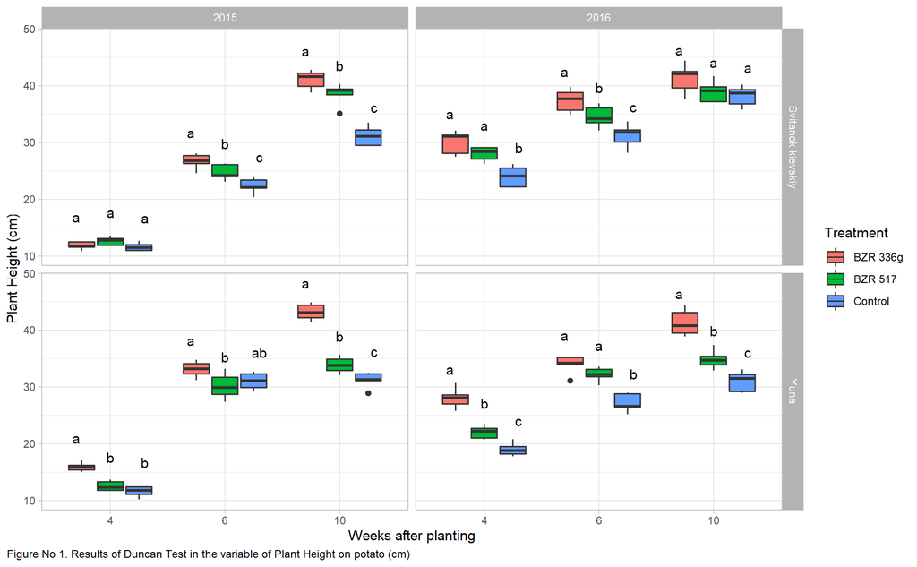

```r
library(agricolae)
library(ggplot2)
library(ggpubr)
#Plant Height Duncan Graph

ggplot(Data.Cultivars.Final, aes(x=`Weeks after planting`, y=Plant.Height, fill=Treatment))+ylab("Plant Height (cm)")+
  geom_boxplot()+
  facet_grid(Cultivar~Year)+
  theme_light()+
  geom_text(data = LettersPH,
            mapping = aes(x = Weeks.after.planting,
                          y = mea + 5,
                          label = letra),
            position = position_dodge(0.9))+
  labs(caption = "Figure No 1. Results of Duncan Test in the variable of Plant Height on potato (cm)") +
  theme(plot.caption.position = "plot",
        plot.caption = element_text(hjust = 0))
```

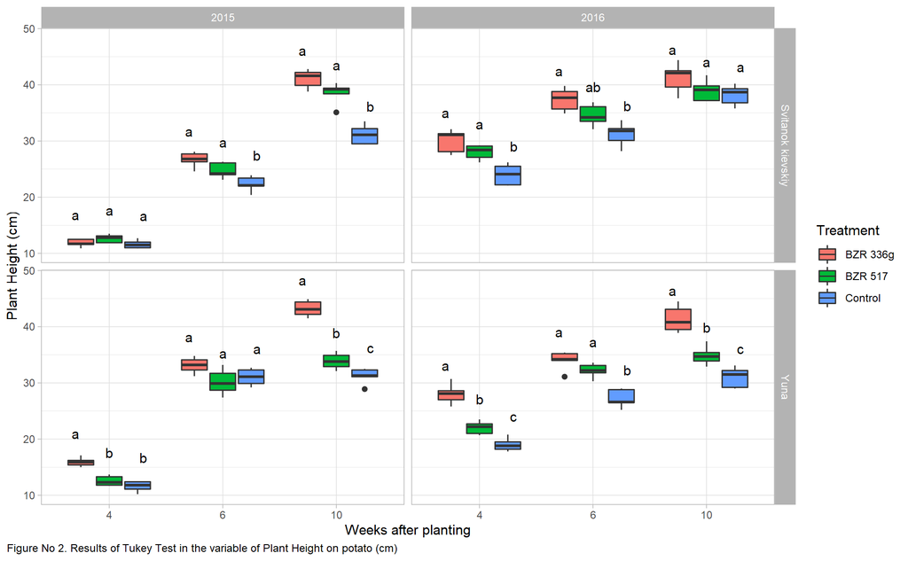

```r
#Plant Height Tukey Graph

ggplot(Data.Cultivars.Final, aes(x=`Weeks after planting`, y=Plant.Height, fill=Treatment))+ylab("Plant Height (cm)")+
  geom_boxplot()+
  facet_grid(Cultivar~Year)+
  theme_light()+
  geom_text(data = LettersPHz,
            mapping = aes(x = Weeks.after.planting,
                          y = mea + 5,
                          label = letra),
            position = position_dodge(0.9))+
  labs(caption = "Figure No 2. Results of Tukey Test in the variable of Plant Height on potato (cm)") +
  theme(plot.caption.position = "plot",
        plot.caption = element_text(hjust = 0))
```

```r
#Residuals Plant Height
anova.ph<-aov(Plant.Height~Treatment+`Weeks after planting`+Year, data=Data.Cultivars.Final) #anova
anova.ph.sqrt <- aov(sqrt(Plant.Height)~Treatment+`Weeks after planting`+Year, data=Data.Cultivars.Final) #square root
shapiro.test(anova.ph$residuals) #0.0329 anormal
```

```
##
##  Shapiro-Wilk normality test
##
## data:  anova.ph$residuals
## W = 0.9836, p-value = 0.03299
```

```r
shapiro.test(anova.ph.sqrt$residuals) #0.02933
```

```
##
##  Shapiro-Wilk normality test
##
## data:  anova.ph.sqrt$residuals
## W = 0.98322, p-value = 0.02933
```

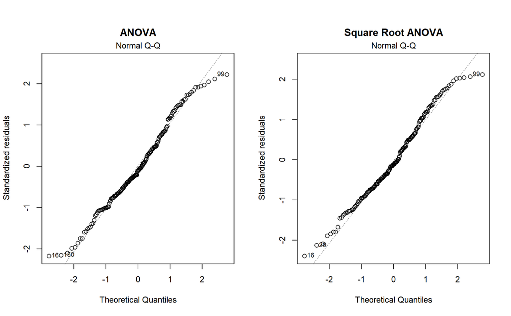

Figure No 3. Normality of Residuals Plant Height

```r
par(mfrow = c(1, 2), oma = c(0, 0, 1.1, 0))
plot(anova.ph, main = "ANOVA", which = 2, ask = F,sub.caption = "")
plot(anova.ph.sqrt, main = "Square Root ANOVA", which = 2, ask = F,sub.caption = "")
```

```r
#AIC and BIC Plant Height
AIC(anova.ph, anova.ph.sqrt)
```

```
##               df       AIC
## anova.ph       7 1001.9581
## anova.ph.sqrt  7  187.3949
```

```r
BIC(anova.ph, anova.ph.sqrt)
```

```
##               df       BIC
## anova.ph       7 1024.3088
## anova.ph.sqrt  7  209.7456
```

**1.2 Disease Incidence**

The Duncan and Tukey tests had few differences.Only in year 2015 in cultivar Svitanok kievski it can be seen a difference between the groups (Figures 4 and 5). The Shapiro-Wilk normality test was performed for Anova and Square Root Anova because in Anova p was lower than 0.05, that means that the data significantly deviate from a normal distribution (Figure 6).

Taking into account the incidence of the disease, at week 10, we can observe that the BZR 336 treatment was the one that caused the lowest incidence in both years and in both cultivars when using the Duncan test. In the Tukey test, this difference was not significant between treatments on cultivar Svitanok kievski in 2015.

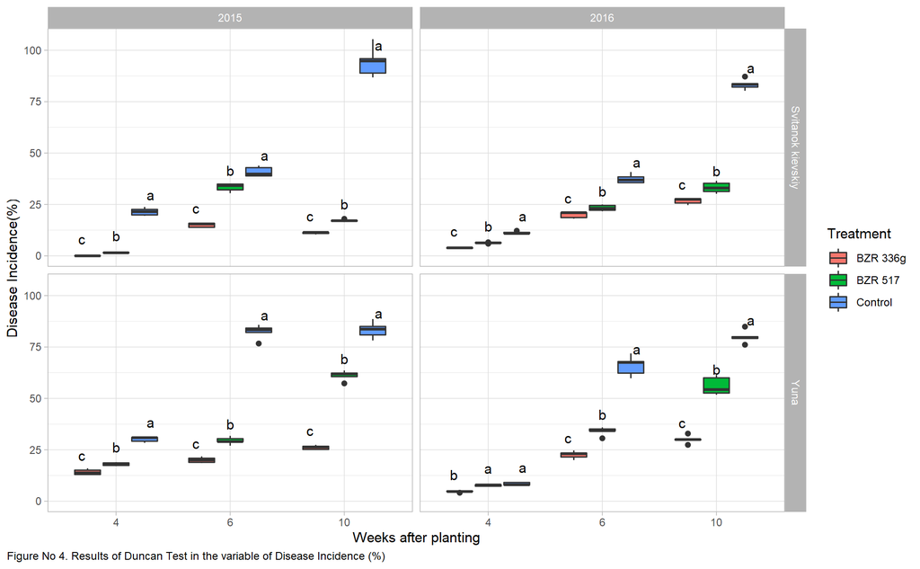

```r
#Duncan Graph Disease Incidence
ggplot(Data.Cultivars.Final, aes(x=`Weeks after planting`, y=Disease.Incidence, fill=Treatment))+ylab("Disease Incidence(%)")+
  geom_boxplot()+
  facet_grid(Cultivar~Year)+
  theme_light()+
  geom_text(data = LettersDI,
            mapping = aes(x = Weeks.after.planting,
                          y = mea + 8,
                          label = letra),
            position = position_dodge(0.9))+
  labs(caption = "Figure No 4. Results of Duncan Test in the variable of Disease Incidence (%)") +
  theme(plot.caption.position = "plot",
        plot.caption = element_text(hjust = 0))
```

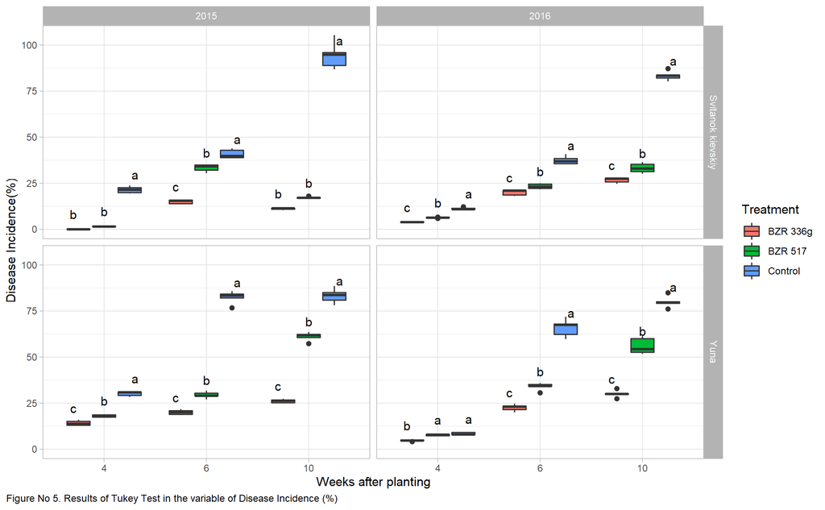

```r
#Tukey Graph Disease Incidence
ggplot(Data.Cultivars.Final, aes(x=`Weeks after planting`, y=Disease.Incidence, fill=Treatment))+ylab("Disease Incidence(%)")+
  geom_boxplot()+
  facet_grid(Cultivar~Year)+
  theme_light()+
  geom_text(data = LettersDIz,
            mapping = aes(x = Weeks.after.planting,
                          y = mea + 8,
                          label = letra),
            position = position_dodge(0.9))+
  labs(caption = "Figure No 5. Results of Tukey Test in the variable of Disease Incidence (%)") +
  theme(plot.caption.position = "plot",
        plot.caption = element_text(hjust = 0))
```

```r
#Residuals Disease Incidence
anova.di<-aov(Disease.Incidence~Treatment+`Weeks after planting`+Year, data=Data.Cultivars.Final) #anova
anova.di.sqrt <- aov(sqrt(Disease.Incidence)~Treatment+`Weeks after planting`+Year, data=Data.Cultivars.Final) #square root
shapiro.test(anova.di$residuals) #0.03132 anormal
```

```
##
##  Shapiro-Wilk normality test
##
## data:  anova.di$residuals
## W = 0.98343, p-value = 0.03132
```

```r
shapiro.test(anova.di.sqrt$residuals) #0.001165
```

```
##
##  Shapiro-Wilk normality test
##
## data:  anova.di.sqrt$residuals
## W = 0.97222, p-value = 0.001165
```

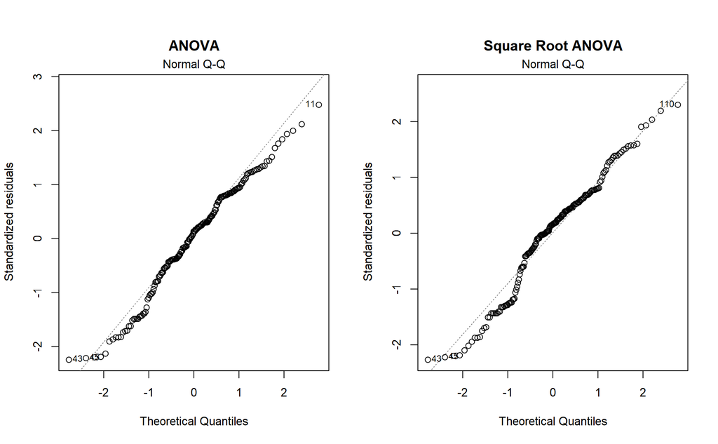

Figure No. 6 Normality of Residuals Disease Incidence

```r
par(mfrow = c(1, 2), oma = c(0, 0, 1.1, 0))
plot(anova.di, main = "ANOVA", which = 2, ask = F,sub.caption = "")
plot(anova.di.sqrt, main = "Square Root ANOVA", which = 2, ask = F,sub.caption = "")
```

```r
#AIC and BIC Disease Incidence
AIC(anova.di, anova.di.sqrt)
```

```
##               df       AIC
## anova.di       7 1454.2804
## anova.di.sqrt  7  549.3612
```

```r
BIC(anova.di, anova.di.sqrt)
```

```
##               df       BIC
## anova.di       7 1476.6311
## anova.di.sqrt  7  571.7119
```

**1.3 Disease Severity**

The Duncan and Tukey tests did not have differences (Figures 7 and 8). The Shapiro-Wilk normality test was performed for Anova and Square Root Anova because in Anova p was lower than 0.05, that means that the data significantly deviate from a normal distribution (Figure 9).

Taking into account the disease severity, at week 10, we can observe that the BZR 336 treatment was the one that caused the lowest severity in both years and in both cultivars in both tests. However, this difference was not significant between the two treatments on cultivar Svitanok kievski in 2015, in both tests.

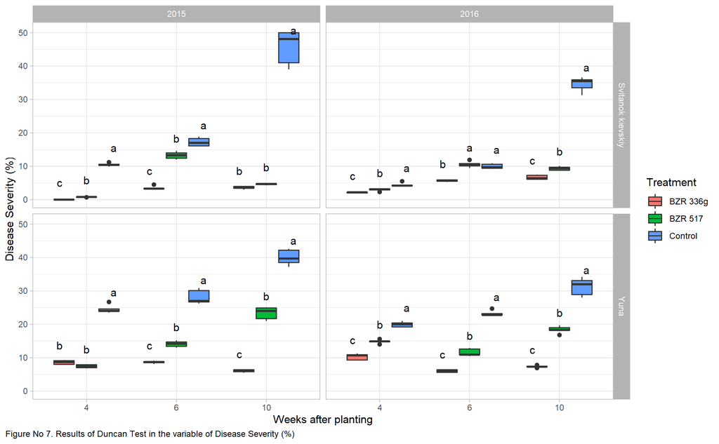

```r
#Duncan Graph Disease Severity
ggplot(Data.Cultivars.Final, aes(x=`Weeks after planting`, y=Disease.Severity, fill=Treatment))+ylab("Disease Severity (%)")+
  geom_boxplot()+
  facet_grid(Cultivar~Year)+
  theme_light()+
  geom_text(data = LettersDS,
            mapping = aes(x = Weeks.after.planting,
                          y = mea + 5,
                          label = letra),
            position = position_dodge(0.9))+
  labs(caption = "Figure No 7. Results of Duncan Test in the variable of Disease Severity (%)") +
  theme(plot.caption.position = "plot",
        plot.caption = element_text(hjust = 0))
```

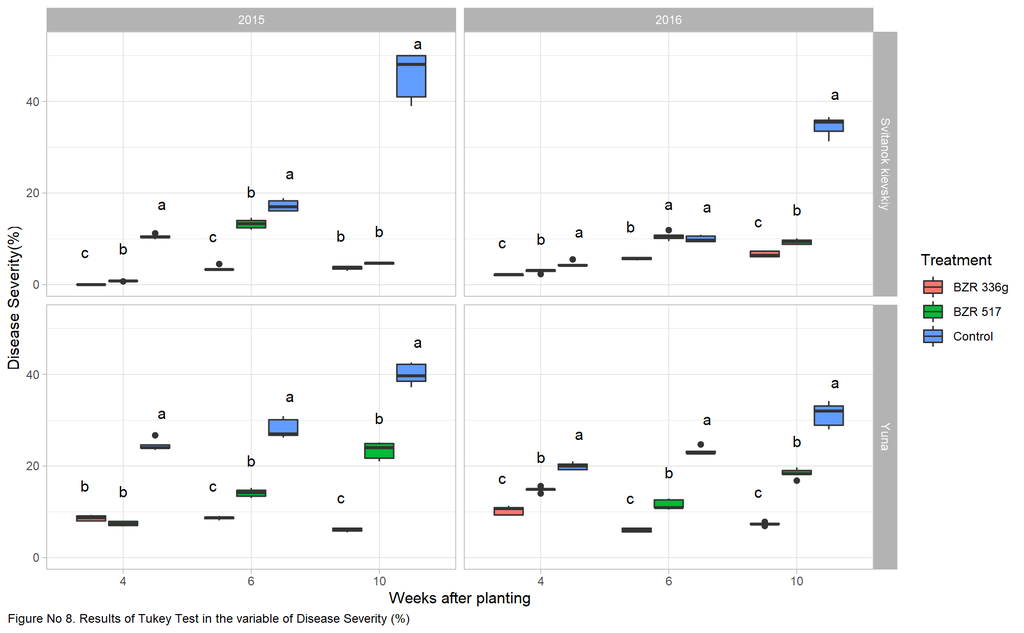

```r
#Tukey Graph Disease Severity

ggplot(Data.Cultivars.Final, aes(x=`Weeks after planting`, y=Disease.Severity, fill=Treatment))+ylab("Disease Severity(%)")+
  geom_boxplot()+
  facet_grid(Cultivar~Year)+
  theme_light()+
  geom_text(data = LettersDSz,
            mapping = aes(x = Weeks.after.planting,
                          y = mea + 7,
                          label = letra),
            position = position_dodge(0.9))+
  labs(caption = "Figure No 8. Results of Tukey Test in the variable of Disease Severity (%)") +
  theme(plot.caption.position = "plot",
        plot.caption = element_text(hjust = 0))
```

```r
#Residuals Disease Severity
anova.ds<-aov(Disease.Severity~Treatment+`Weeks after planting`+Year, data=Data.Cultivars.Final) #anova
anova.ds.sqrt <- aov(sqrt(Disease.Severity)~Treatment+`Weeks after planting`+Year, data=Data.Cultivars.Final) #square root
shapiro.test(anova.ds$residuals) #0.002356 anormal
```

```
##
##  Shapiro-Wilk normality test
##
## data:  anova.ds$residuals
## W = 0.97475, p-value = 0.002356
```

```r
shapiro.test(anova.ds.sqrt$residuals) #0.0009698
```

```
##
##  Shapiro-Wilk normality test
##
## data:  anova.ds.sqrt$residuals
## W = 0.97155, p-value = 0.0009698
```

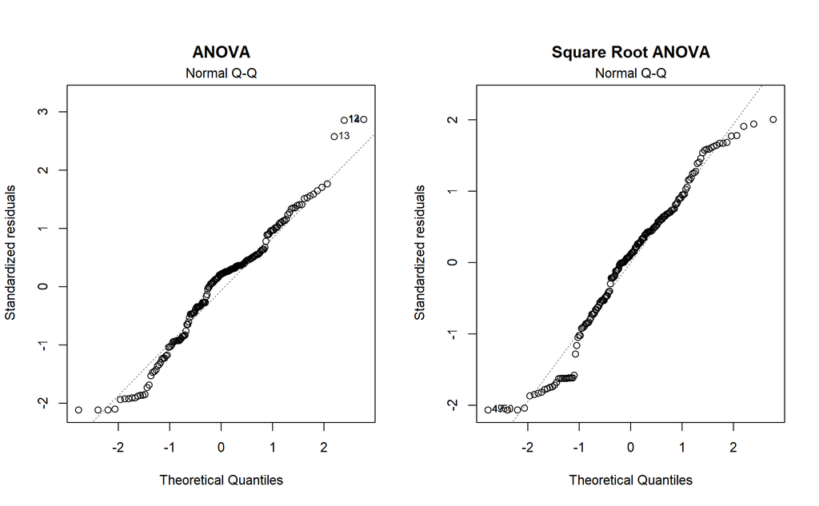

```r
par(mfrow = c(1, 2), oma = c(0, 0, 1.1, 0))
plot(anova.ds, main = "ANOVA", which = 2, ask = F,sub.caption = "")
plot(anova.ds.sqrt, main = "Square Root ANOVA", which = 2, ask = F,sub.caption = "")
```

```r
#AIC and BIC Disease Severity
AIC(anova.ds, anova.ds.sqrt)
```

```
##               df      AIC
## anova.ds       7 1213.955
## anova.ds.sqrt  7  500.044
```

```r
BIC(anova.ds, anova.ds.sqrt)
```

```
##               df       BIC
## anova.ds       7 1236.3059
## anova.ds.sqrt  7  522.3947
```

**1.4 Number of stems**

The Duncan and Tukey tests had few differences.Only in year 2016 in cultivar Yuna in the control it can be seen a difference between the groups (Figures 10 and 11). The Shapiro-Wilk normality test was performed for Anova and Square Root Anova because in Anova p was lower than 0.05, that means that the data significantly deviate from a normal distribution (Figure 12).

Taking into account the number of stems, at week 10, we can see that the BZR 336 treatment generated the highest number of stems in both years and in both cultivars in both tests. However, this difference was not significant between the two treatments on cultivar Yuna in 2015, in both tests.

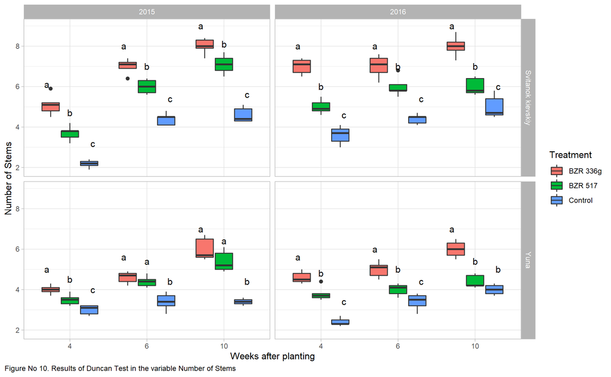

```r
#Duncan Graph Stems
ggplot(Data.Cultivars.Final, aes(x=`Weeks after planting`, y=Stems, fill=Treatment))+ylab("Number of Stems")+
  geom_boxplot()+
  facet_grid(Cultivar~Year)+
  theme_light()+
  geom_text(data = LettersST,
            mapping = aes(x = Weeks.after.planting,
                          y = mea + 1,
                          label = letra),
            position = position_dodge(0.9))+
  labs(caption = "Figure No 10. Results of Duncan Test in the variable Number of Stems") +
  theme(plot.caption.position = "plot",
        plot.caption = element_text(hjust = 0))
```

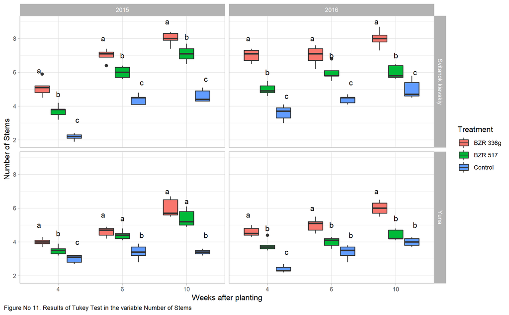

```r
#Tukey Graph Stems
ggplot(Data.Cultivars.Final, aes(x=`Weeks after planting`, y=Stems, fill=Treatment))+ylab("Number of Stems")+
  geom_boxplot()+
  facet_grid(Cultivar~Year)+
  theme_light()+
  geom_text(data = LettersSTz,
            mapping = aes(x = Weeks.after.planting,
                          y = mea + 1,
                          label = letra),
            position = position_dodge(0.9))+
  labs(caption = "Figure No 11. Results of Tukey Test in the variable Number of Stems") +
  theme(plot.caption.position = "plot",
        plot.caption = element_text(hjust = 0))
```

```r
#Residuals Stems
anova.st<-aov(Stems~Treatment+`Weeks after planting`+Year, data=Data.Cultivars.Final) #anova
anova.st.sqrt <- aov(sqrt(Stems)~Treatment+`Weeks after planting`+Year, data=Data.Cultivars.Final) #square root
shapiro.test(anova.st$residuals) #0.007876 anormal
```

```
##
##  Shapiro-Wilk normality test
##
## data:  anova.st$residuals
## W = 0.9789, p-value = 0.007876
```

```r
shapiro.test(anova.st.sqrt$residuals) #0.002167
```

```
##
##  Shapiro-Wilk normality test
##
## data:  anova.st.sqrt$residuals
## W = 0.97445, p-value = 0.002167
```

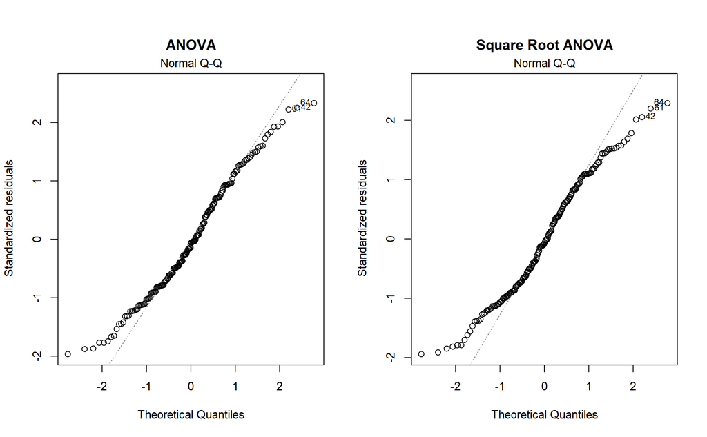

Figure No. 12 Normality of Residuals Stems

```r
par(mfrow = c(1, 2), oma = c(0, 0, 1.1, 0))
plot(anova.st, main = "ANOVA", which = 2, ask = F,sub.caption = "")
plot(anova.st.sqrt, main = "Square Root ANOVA", which = 2, ask = F,sub.caption = "")
```

```r
#AIC and BIC Stems
AIC(anova.st, anova.st.sqrt)
```

```
##               df       AIC
## anova.st       7 495.88079
## anova.st.sqrt  7 -50.13636
```

```r
BIC(anova.st, anova.st.sqrt)
```

```
##               df       BIC
## anova.st       7 518.23149
## anova.st.sqrt  7 -27.78566
```

**2) Effect of *B. velezens* strains on the biomass distribution of daughter tubers of two potato cultivars differed by disease resistance to *R. solani* and total yield during 2015 and 2016 growing seasons in Western Siberia.**

**2.1 Biomass distribution**

The Duncan and Tukey tests did not have differences (Figures 13 and 14). The Shapiro-Wilk normality test was performed for Anova and Square Root Anova but this case in Anova p was higher than 0.05, that means that the data has a normal distribution (Figure 15).

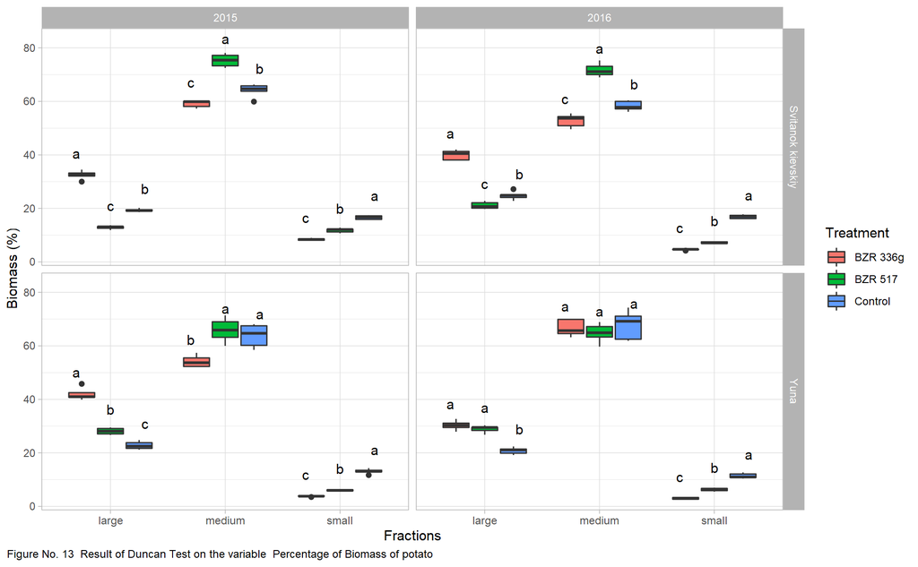

```r
#Biomass Graph Duncan
ggplot(BiomassDistribution, aes(x=`Fractions`, y=Percentage.Biomass, fill=Treatment))+ylab("Biomass (%)")+
  geom_boxplot()+
  facet_grid(Cultivar~Year)+
  theme_light()+
  geom_text(data = LettersPH1,
            mapping = aes(x = Fractions,
                          y = mea + 8,
                          label = letra),
            position = position_dodge(0.9))+
  labs(caption = "Figure No. 13  Result of Duncan Test on the variable  Percentage of Biomass of potato") +
  theme(plot.caption.position = "plot",
        plot.caption = element_text(hjust = 0))
```

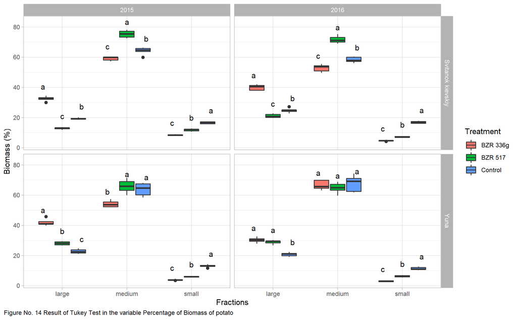

```r
#Biomass Graph Tukey
ggplot(BiomassDistribution, aes(x=`Fractions`, y=Percentage.Biomass, fill=Treatment))+ ylab("Biomass (%)")+
  geom_boxplot()+
  facet_grid(Cultivar~Year)+
  theme_light()+
  geom_text(data = LetterstPH11,
            mapping = aes(x = Fractions,
                          y = mea + 8,
                          label = letra),
            position = position_dodge(0.9))+
  labs(caption = "Figure No. 14 Result of Tukey Test in the variable Percentage of Biomass of potato") +
  theme(plot.caption.position = "plot",
        plot.caption = element_text(hjust = 0))
```

```r
#Residuals Biomass
anova.biomass<-aov(Percentage.Biomass~Treatment+`Fractions`+Year, data=BiomassDistribution) #anova
anova.biomass.sqrt <- aov(sqrt(Percentage.Biomass)~Treatment+`Fractions`+Year, data=BiomassDistribution) #square root
shapiro.test(anova.biomass$residuals) #0.06424
```

```
##
##  Shapiro-Wilk normality test
##
## data:  anova.biomass$residuals
## W = 0.98573, p-value = 0.06424
```

```r
shapiro.test(anova.biomass.sqrt$residuals) #0.3364
```

```
##
##  Shapiro-Wilk normality test
##
## data:  anova.biomass.sqrt$residuals
## W = 0.99117, p-value = 0.3364
```

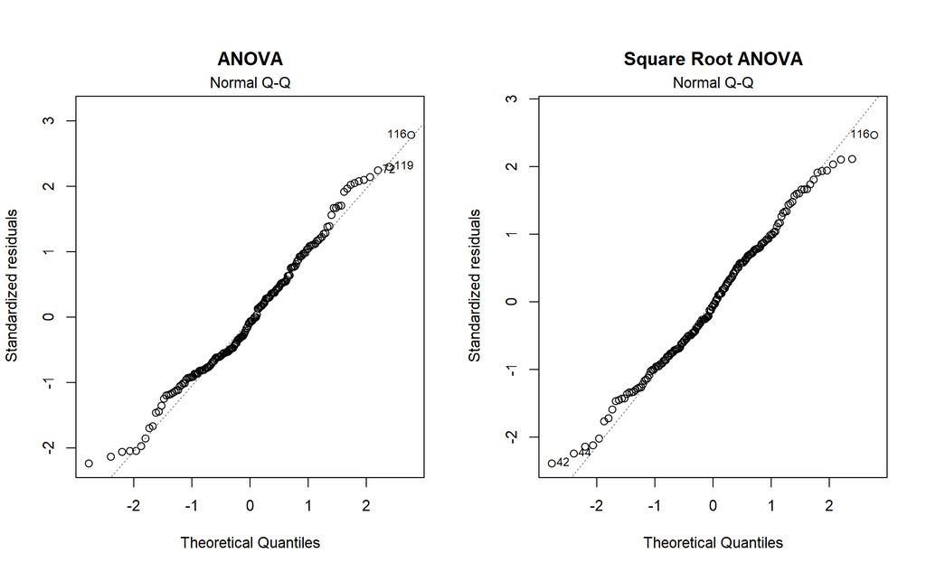

Figure No. 15 Normality of Residuals Percentage of Biomass

```r
par(mfrow = c(1, 2), oma = c(0, 0, 1.1, 0))
plot(anova.biomass, main = "ANOVA", which = 2, ask = F,sub.caption = "")
plot(anova.biomass.sqrt, main = "Square Root ANOVA", which = 2, ask = F,sub.caption = "")
```

```r
#AIC and BIC Biomass
AIC(anova.biomass, anova.biomass.sqrt)
```

```
##                    df       AIC
## anova.biomass       7 1214.6216
## anova.biomass.sqrt  7  387.9373
```

```r
BIC(anova.biomass, anova.biomass.sqrt)
```

```
##                    df      BIC
## anova.biomass       7 1236.972
## anova.biomass.sqrt  7  410.288
```

**2.2 Yield of Potato**

The Duncan and Tukey tests did not have differences (Figures 16 and 17). The Shapiro-Wilk normality test was performed for Anova with a p-vañue higher than 0.05 both years and cultivars, that means that the data has a normal distribution (Figure 18).

Taking into account the yield of potato, we can observe that in both tests and in both years, in cultivar Svitanok kievski, the BZR 336g treatment generated the highest yield. However, for the cultivar Yuna, the difference between the two treatments was not significant at any time.

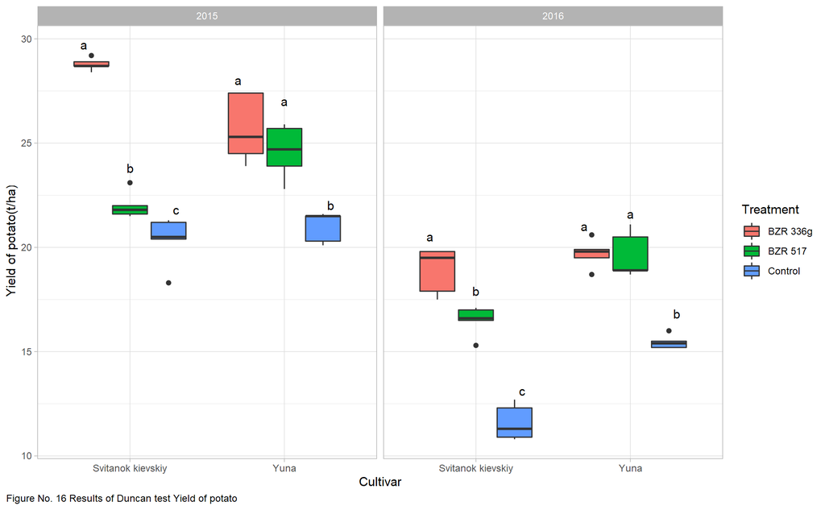

```r
library(ggplot2)
library(ggpubr)
#Duncan Yield Graph
#Create data frame
dat_text <- data.frame(
  label = letter1,
  Year   = c(rep(2015,6),rep(2016,6)),
  Treatment = rep(levels(as.factor(YieldOfPotato$Treatment)),4),
  Cultivar= c("Svitanok kievskiy","Svitanok kievskiy","Svitanok kievskiy","Yuna","Yuna","Yuna","Svitanok kievskiy","Svitanok kievskiy","Svitanok kievskiy","Yuna","Yuna","Yuna"))

duncanyieldgraph <- ggplot(YieldOfPotato, aes(x=`Cultivar`, y=Yield.Potato, fill=Treatment))+ylab("Yield of potato(t/ha)")+
  geom_boxplot()+
  facet_grid(.~Year)+
  theme_light()+
  geom_text(data = dat_text,
            mapping = aes(x = Cultivar,
                          y = c(29.7, 23.8,21.8, 28,27,22,20.5,17.9,13.1,21,21.6,16.8),
                          label = letter1),
            position = position_dodge(0.9))+
  labs(caption = "Figure No. 16 Results of Duncan test Yield of potato") +
  theme(plot.caption.position = "plot",
        plot.caption = element_text(hjust = 0))
duncanyieldgraph
```

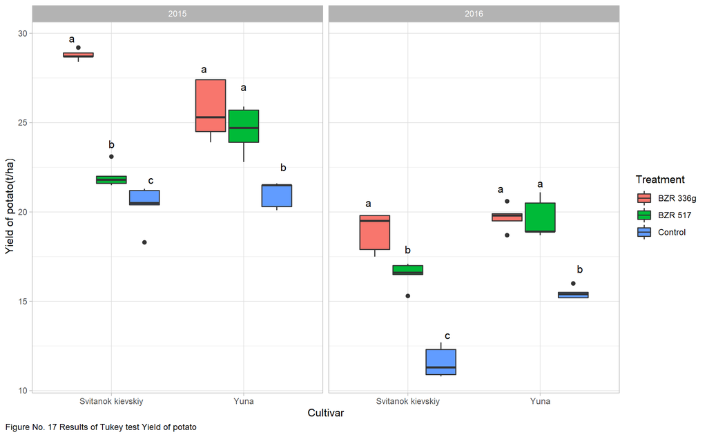

```r
#Tukey Yield Graph
#Create data frame
dat_text1 <- data.frame(
  label = lettert,
  Year   = c(rep(2015,6),rep(2016,6)),
  Treatment = rep(levels(as.factor(YieldOfPotato$Treatment)),4),
  Cultivar= c("Svitanok kievskiy","Svitanok kievskiy","Svitanok kievskiy","Yuna","Yuna","Yuna","Svitanok kievskiy","Svitanok kievskiy","Svitanok kievskiy","Yuna","Yuna","Yuna"))

tukeyyieldgraph <- ggplot(YieldOfPotato, aes(x=`Cultivar`, y=Yield.Potato, fill=Treatment))+ylab("Yield of potato(t/ha)")+
  geom_boxplot()+
  facet_grid(.~Year)+
  theme_light()+
  geom_text(data = dat_text1,
            mapping = aes(x = Cultivar,
                          y = c(29.7, 23.8,21.8, 28,27,22.5,20.5,17.9,13.1,21.3,21.6,16.8),
                          label = lettert),
            position = position_dodge(0.9))+
  labs(caption = "Figure No. 17 Results of Tukey test Yield of potato") +
  theme(plot.caption.position = "plot",
        plot.caption = element_text(hjust = 0))
tukeyyieldgraph
```

```r
#Residuals

#Residuals Yield 2015 Svitanok kievskiy
YieldOfPotato$Cultivar <- factor(YieldOfPotato$Cultivar)
Con <- YieldOfPotato$Cultivar == "Svitanok kievskiy" & YieldOfPotato$Year==2015
d1 <- YieldOfPotato[Con,]
anova.yieldsk<-aov(Yield.Potato~Treatment,data=d1) #anova
anova.yieldsk.sqrt <- aov(sqrt(Yield.Potato)~Treatment,data=d1) #square root
shapiro.test(anova.yieldsk$residuals) #0.0553
```

```
##
##  Shapiro-Wilk normality test
##
## data:  anova.yieldsk$residuals
## W = 0.88445, p-value = 0.0553
```

```r
#shapiro.test(anova.yieldsk.sqrt$residuals) #0.02795

#Residuals Yield 2015 Yuna
YieldOfPotato$Cultivar <- factor(YieldOfPotato$Cultivar)
Con1 <- YieldOfPotato$Cultivar == "Yuna" & YieldOfPotato$Year==2015
d2 <- YieldOfPotato[Con1,]
anova.yieldy<-aov(Yield.Potato~Treatment,data=d2)#anova
anova.yieldy.sqrt <- aov(sqrt(Yield.Potato)~Treatment,data=d2) #square root
shapiro.test(anova.yieldy$residuals) #0.4242
```

```
##
##  Shapiro-Wilk normality test
##
## data:  anova.yieldy$residuals
## W = 0.94319, p-value = 0.4242
```

```r
#shapiro.test(anova.yieldy.sqrt$residuals) #0.3887

#Residuals Yield 2016 Svitanok kievskiy
YieldOfPotato$Cultivar <- factor(YieldOfPotato$Cultivar)
Con1234 <- YieldOfPotato$Cultivar == "Svitanok kievskiy" & YieldOfPotato$Year==2016
d1234 <- YieldOfPotato[Con1234,]
anova.yieldsk6<-aov(Yield.Potato~Treatment,data=d1234)#anova
anova.yieldsk6.sqrt <- aov(sqrt(Yield.Potato)~Treatment,data=d1234)#square root
shapiro.test(anova.yieldsk6$residuals) #0.1674
```

```
##
##  Shapiro-Wilk normality test
##
## data:  anova.yieldsk6$residuals
## W = 0.916, p-value = 0.1674
```

```r
#shapiro.test(anova.yieldsk6.sqrt$residuals) #0.1481

#Residuals Yield 2016 Yuna
YieldOfPotato$Cultivar <- factor(YieldOfPotato$Cultivar)
Con12345 <- YieldOfPotato$Cultivar == "Yuna" & YieldOfPotato$Year==2016
d2345 <- YieldOfPotato[Con12345,]
anova.yieldy6<-aov(Yield.Potato~Treatment,data=d2345) #anova
anova.yieldy6.sqrt <- aov(sqrt(Yield.Potato)~Treatment,data=d2345) #square root
shapiro.test(anova.yieldy6$residuals) #0.6108
```

```
##
##  Shapiro-Wilk normality test
##
## data:  anova.yieldy6$residuals
## W = 0.95526, p-value = 0.6108
```

```r
#shapiro.test(anova.yieldy6.sqrt$residuals) #0.6299
```

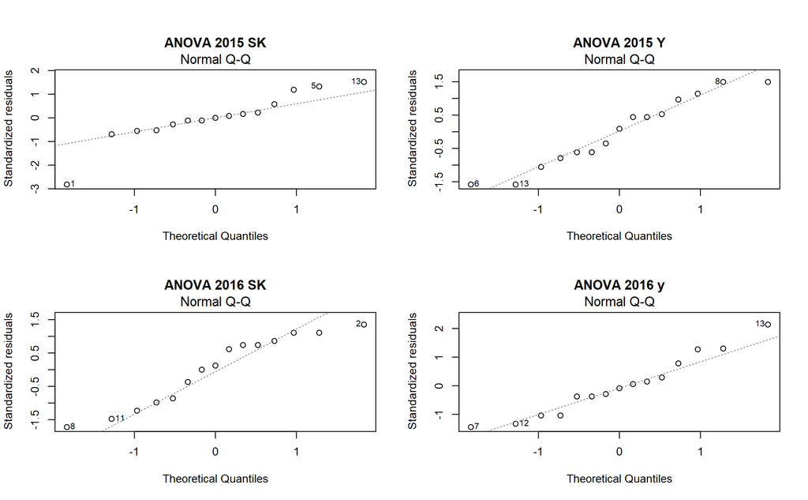

Figure No. 18 Normality of Residuals Yield of Potato

```r
#Graph
par(mfrow = c(2, 2), oma = c(0, 0, 1.1, 0))
p1 <- plot(anova.yieldsk, main = "ANOVA 2015 SK", which = 2, ask = F,sub.caption = "")
p2 <- plot(anova.yieldy, main = "ANOVA 2015 Y", which = 2, ask = F,sub.caption = "")
p3 <- plot(anova.yieldsk6, main = "ANOVA 2016 SK", which = 2, ask = F,sub.caption = "")
p4 <- plot(anova.yieldy6, main = "ANOVA 2016 y", which = 2, ask = F,sub.caption = "")
```

**3) *In vitro* antifungal activity of *Bacillus strains* against the phytopathogenic fungus *R. solani*, isolated from infected potato tubers**

**3.1 Growth of the diameter of the colonies of *R. solani* under the influence of *B. velenzis* after 3, 5 and 7 days**

Significant differences were observed between the treatments and control over time (Figure 19).

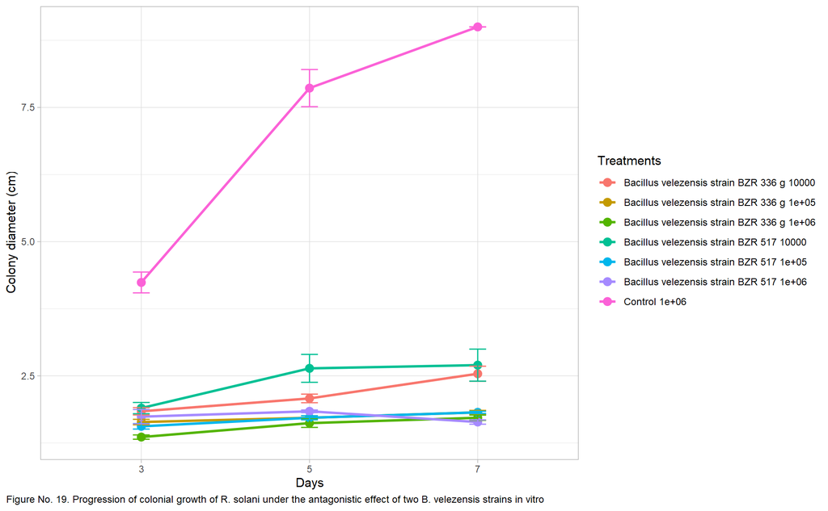

```r
##Graph the influence of treatments on the fungal diameter growth after 3, 5 and 7 days.

#install.packages("ggplot2")

library(ggplot2)

ggplot(plot.means, aes(x = Days,
                       y = mean,
                       group=Trat,
                       color=Trat)) +
  geom_point(size = 3) +
  geom_line(size = 1) +
  geom_errorbar(aes(ymin=mean-se,
                    ymax=mean+se),
                width = .1)+
  labs(caption = "Figure No. 19. Progression of colonial growth of R. solani under the antagonistic effect of two B. velezensis strains in vitro",
       x = "Days",
       y = "Colony diameter (cm)",
       color = "Treatment") +theme_light()+ guides(col=guide_legend("Treatments")) +
  theme(plot.caption.position = "plot",
        plot.caption = element_text(hjust = 0))
```

**3.2 Growth of the diameter of the colonies of *R. solani* under the influence of *B. velenzis* after 3, 5 and 7 days**

Little differences were observed between Duncan and Tukey analyzes for *R. solani* colony growth at 3 and 5 days. However, there were no differences between both analyzes at 7 days (Figures 20 and 21). The treatments with the best performance were both *B. velezensis* strains: BZR 517 and BZR 336g, in their medium and high concentrations: 10^5 CFU/mL and 10^6 CFU/mL, generating the lower colony growth after 7 days.

The Shapiro-Wilk normality test was performed for ANOVA, the p values at 3, 5 and 7 days were less than alpha=0.05, wich means that the data do not follow a normal distribution (Figure 22).

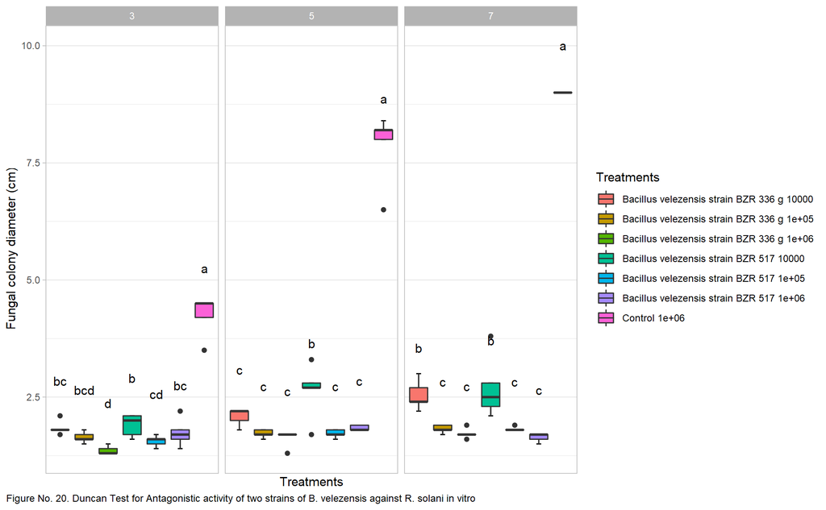

```r
## Combine Duncan graphs for 3, 5 and 7 d

#library(ggplot2)
#library(ggpubr)
#theme_set(theme_pubr())

DunLetters <- data.frame(Days=c(rep(3,7),rep(5,7),rep(7,7)),
                         Trat=c("Bacillus velezensis strain BZR 336 g 10000","Bacillus velezensis strain BZR 336 g 1e+05",
                                "Bacillus velezensis strain BZR 336 g 1e+06","Bacillus velezensis strain BZR 517 10000",
                                "Bacillus velezensis strain BZR 517 1e+05","Bacillus velezensis strain BZR 517 1e+06",
                                "Control 1e+06","Bacillus velezensis strain BZR 336 g 10000","Bacillus velezensis strain BZR 336 g 1e+05",
                                "Bacillus velezensis strain BZR 336 g 1e+06","Bacillus velezensis strain BZR 517 10000",
                                "Bacillus velezensis strain BZR 517 1e+05","Bacillus velezensis strain BZR 517 1e+06",
                                "Control 1e+06","Bacillus velezensis strain BZR 336 g 10000","Bacillus velezensis strain BZR 336 g 1e+05",
                                "Bacillus velezensis strain BZR 336 g 1e+06","Bacillus velezensis strain BZR 517 10000",
                                "Bacillus velezensis strain BZR 517 1e+05","Bacillus velezensis strain BZR 517 1e+06",
                                "Control 1e+06"),
                         Mean=plot.means$mean,
                         SE=plot.means$se,
                         label=c("bc","bcd","d","b","cd","bc","a","c","c","c","b","c","c","a","b","c","c","b","c","c","a"))

DunBox <- ggplot(AntagonisticActivity, aes(x=`Trat`, y=Colony.Diameter, fill=Trat))+xlab("Treatments")+ylab("Fungal colony diameter (cm)")+
  stat_boxplot(geom = "errorbar",
               width = 0.2) +
  geom_boxplot()+
  theme_light()+
  geom_text(data = DunLetters,
            mapping = aes(x = Trat,
                          y = Mean+1,
                          label=label),
            position = position_dodge(0.9))+
  facet_grid(.~Days)+
  labs(caption = "Figure No. 20. Duncan Test for Antagonistic activity of two strains of B. velezensis against R. solani in vitro") +
  scale_x_discrete(("Treatments"),limitedLabels("Treatments"))+
  scale_fill_discrete(("Treatments"))+
  theme(plot.caption.position = "plot",
        plot.caption = element_text(hjust = 0))

DunBox
```

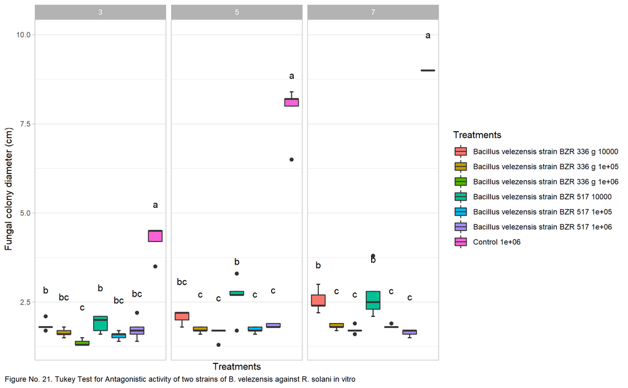

```r
## Tukey graphs for 3, 5 and 7 d

#library(ggplot2)
#library(ggpubr)
#theme_set(theme_pubr())

TukLetters <- data.frame(Days=c(rep(3,7),rep(5,7),rep(7,7)),
                         Trat=c("Bacillus velezensis strain BZR 336 g 10000","Bacillus velezensis strain BZR 336 g 1e+05",
                                "Bacillus velezensis strain BZR 336 g 1e+06","Bacillus velezensis strain BZR 517 10000",
                                "Bacillus velezensis strain BZR 517 1e+05","Bacillus velezensis strain BZR 517 1e+06",
                                "Control 1e+06","Bacillus velezensis strain BZR 336 g 10000","Bacillus velezensis strain BZR 336 g 1e+05",
                                "Bacillus velezensis strain BZR 336 g 1e+06","Bacillus velezensis strain BZR 517 10000",
                                "Bacillus velezensis strain BZR 517 1e+05","Bacillus velezensis strain BZR 517 1e+06",
                                "Control 1e+06","Bacillus velezensis strain BZR 336 g 10000","Bacillus velezensis strain BZR 336 g 1e+05",
                                "Bacillus velezensis strain BZR 336 g 1e+06","Bacillus velezensis strain BZR 517 10000",
                                "Bacillus velezensis strain BZR 517 1e+05","Bacillus velezensis strain BZR 517 1e+06",
                                "Control 1e+06"),
                         Mean=plot.means$mean,
                         SE=plot.means$se,
                         label=c("b","bc","c","b","bc","bc","a","bc","c","c","b","c","c","a","b","c","c","b","c","c","a"))

TukBox <- ggplot(AntagonisticActivity, aes(x=`Trat`, y=Colony.Diameter, fill=Trat))+xlab("Treatments")+ylab("Fungal colony diameter (cm)")+
  stat_boxplot(geom = "errorbar",
               width = 0.2) +
  geom_boxplot()+
  theme_light()+
  geom_text(data = TukLetters,
            mapping = aes(x = Trat,
                          y = Mean+1,
                          label=label),
            position = position_dodge(0.9))+
  facet_grid(.~Days)+
  labs(caption = "Figure No. 21. Tukey Test for Antagonistic activity of two strains of B. velezensis against R. solani in vitro") +
  scale_x_discrete(("Treatments"),limitedLabels("Treatments"))+
  scale_fill_discrete(("Treatments"))+
  theme(plot.caption.position = "plot",
        plot.caption = element_text(hjust = 0))

TukBox
```

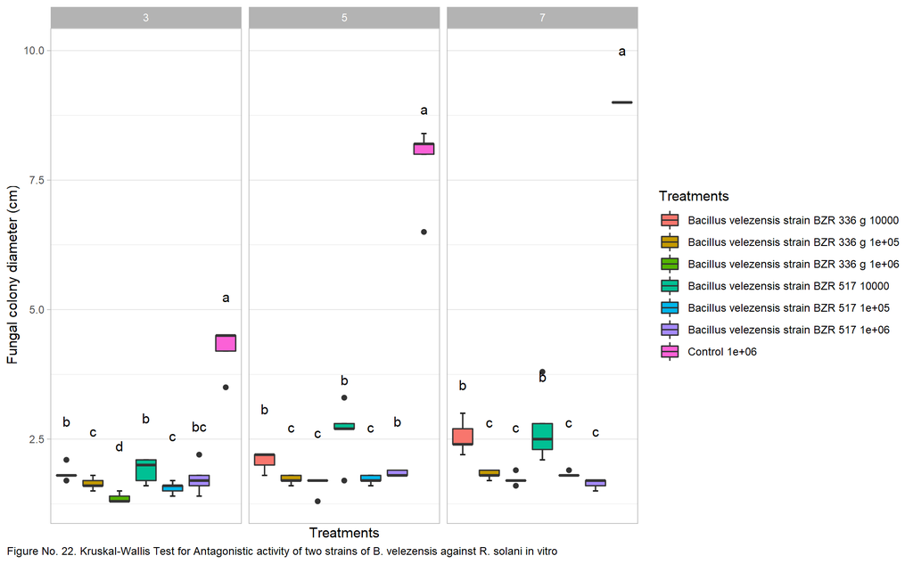

```r
## Kruskal-Wallis graphs for 3, 5 and 7 d

library(ggplot2)
library(ggpubr)
theme_set(theme_pubr())

KWLetters <- data.frame(Days=c(rep(3,7),rep(5,7),rep(7,7)),
                         Trat=c("Bacillus velezensis strain BZR 336 g 10000","Bacillus velezensis strain BZR 336 g 1e+05",
                                "Bacillus velezensis strain BZR 336 g 1e+06","Bacillus velezensis strain BZR 517 10000",
                                "Bacillus velezensis strain BZR 517 1e+05","Bacillus velezensis strain BZR 517 1e+06",
                                "Control 1e+06","Bacillus velezensis strain BZR 336 g 10000","Bacillus velezensis strain BZR 336 g 1e+05",
                                "Bacillus velezensis strain BZR 336 g 1e+06","Bacillus velezensis strain BZR 517 10000",
                                "Bacillus velezensis strain BZR 517 1e+05","Bacillus velezensis strain BZR 517 1e+06",
                                "Control 1e+06","Bacillus velezensis strain BZR 336 g 10000","Bacillus velezensis strain BZR 336 g 1e+05",
                                "Bacillus velezensis strain BZR 336 g 1e+06","Bacillus velezensis strain BZR 517 10000",
                                "Bacillus velezensis strain BZR 517 1e+05","Bacillus velezensis strain BZR 517 1e+06",
                                "Control 1e+06"),
                         Mean=plot.means$mean,
                         SE=plot.means$se,
                         label=c("b","c","d","b","c","bc","a","b","c","c","b","c","b","a","b","c","c","b","c","c","a"))

KWBox <- ggplot(AntagonisticActivity, aes(x=`Trat`, y=Colony.Diameter, fill=Trat))+xlab("Treatments")+ylab("Fungal colony diameter (cm)")+
  stat_boxplot(geom = "errorbar",
               width = 0.2) +
  geom_boxplot()+
  theme_light()+
  geom_text(data = KWLetters,
            mapping = aes(x = Trat,
                          y = Mean+1,
                          label=label),
            position = position_dodge(0.9))+
  facet_grid(.~Days)+
  labs(caption = "Figure No. 22. Kruskal-Wallis Test for Antagonistic activity of two strains of B. velezensis against R. solani in vitro") +
  scale_x_discrete(("Treatments"),limitedLabels("Treatments"))+
  scale_fill_discrete(("Treatments"))+
  theme(plot.caption.position = "plot",
        plot.caption = element_text(hjust = 0))

KWBox
```

```r
## Residuals for Antagonistic activity

##Residuals for day 3
library ("agricolae")
Dia <- 3

AntagonisticActivity$Days <- factor(AntagonisticActivity$Days)
Y1 <- AntagonisticActivity$Days==Dia
AA <- AntagonisticActivity[Y1,]

anova.3d <- aov(Colony.Diameter~Trat,data=AA) #anova
anova.3d.sqrt <- aov(sqrt(Colony.Diameter)~Trat,data=AA) #square root
shapiro.test(anova.3d$residuals) #0.01891
```

```
##
##  Shapiro-Wilk normality test
##
## data:  anova.3d$residuals
## W = 0.92423, p-value = 0.01891
```

```r
shapiro.test(anova.3d.sqrt$residuals) #0.3884
```

```
##
##  Shapiro-Wilk normality test
##
## data:  anova.3d.sqrt$residuals
## W = 0.96791, p-value = 0.3884
```

```r
##Residuals for day 5
library ("agricolae")
Dia <- 5

AntagonisticActivity$Days <- factor(AntagonisticActivity$Days)
Y1 <- AntagonisticActivity$Days==Dia
AA <- AntagonisticActivity[Y1,]

anova.5d <- aov(Colony.Diameter~Trat,data=AA) #anova
anova.5d.sqrt <- aov(sqrt(Colony.Diameter)~Trat,data=AA) #square root
shapiro.test(anova.5d$residuals) #1.646 e-06
```

```
##
##  Shapiro-Wilk normality test
##
## data:  anova.5d$residuals
## W = 0.73985, p-value = 1.646e-06
```

```r
shapiro.test(anova.5d.sqrt$residuals) #1.099 e-05
```

```
##
##  Shapiro-Wilk normality test
##
## data:  anova.5d.sqrt$residuals
## W = 0.78604, p-value = 1.099e-05
```

```r
##Residuals for day 7
library ("agricolae")
Dia <- 7

AntagonisticActivity$Days <- factor(AntagonisticActivity$Days)
Y1 <- AntagonisticActivity$Days==Dia
AA <- AntagonisticActivity[Y1,]

anova.7d <- aov(Colony.Diameter~Trat,data=AA) #anova
anova.7d.sqrt <- aov(sqrt(Colony.Diameter)~Trat,data=AA) #square root
shapiro.test(anova.7d$residuals) #3.084 e-06
```

```
##
##  Shapiro-Wilk normality test
##
## data:  anova.7d$residuals
## W = 0.7557, p-value = 3.084e-06
```

```r
shapiro.test(anova.7d.sqrt$residuals) #2.288 e-05
```

```
##
##  Shapiro-Wilk normality test
##
## data:  anova.7d.sqrt$residuals
## W = 0.80253, p-value = 2.288e-05
```

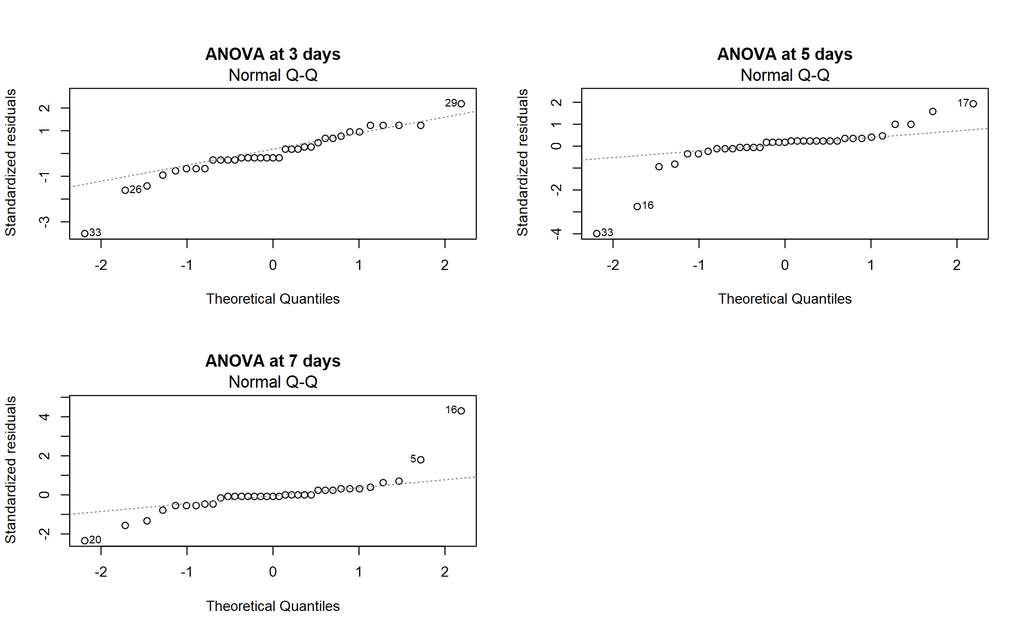

Figure No. 22 Normality of Residuals for Antagonistic activity

```r
#Graph
par(mfrow = c(2, 2), oma = c(0, 0, 1.1, 0))
p1 <- plot(anova.3d, main = "ANOVA at 3 days", which = 2, ask = F,sub.caption = "")
p2 <- plot(anova.5d, main = "ANOVA at 5 days", which = 2, ask = F,sub.caption = "")
p3 <- plot(anova.7d, main = "ANOVA at 7 days", which = 2, ask = F,sub.caption = "")
```

## Conclusions

It can be said that this article in question has very little data to be worked on and therefore the differences between the Tukey and Duncan tests were not significant, which also justifies the authors’ choice of use the Duncan test. About the treatments, in general we can said that the treatment with BZR 336g was what generated the best results in the control of the disease and also in practically all morphological aspects. Only when we talk about the biomass, the BZR 517 treatment showed the best results. In this way, we can say that the article did the best that was possible with the informations that they have.

From the observation that several data sets do not follow a normal distribution, it can be inferred that the authors preferred to perform the mean comparison analysis using the Duncan test, since this can be applied in the same conditions of the Tukey’s test, but with a significance less cautionary. Due to the lack of robustness of Duncan’s test there are some cautions to follow, as many times it cannot be accepted as a proof of differences.